# Lab #12 - Symonds

April 16, 2025

**Install the required packages:**

```r
install.packages(c('dplyr', 'tidyr', 'sf', 'lubridate', 'ggplot2'))
```

**Download the data and extract it to your current working directory:**

- ne_10m_admin_0_countries_NorthAmerica.zip
- BirdBuddy_2023.zip

The BirdBuddy dataset is for creeping on backyard birds, [if that’s your thing.](https://live.mybirdbuddy.com/)

**In this lab, we’ll introduce the concept of a species’ *home range;* the area over which that species regularly occurs during a certain period of time.** Because we have Point data on bird presence, there are two ways to calculate home range:

- As the geographic center (centroid) of all the presence points;
- As the envelope (a polygon) containing all the presence points.

## Downloading the Data

You may need to change the following file paths, after downloading the data.

```r
library(dplyr, warn.conflicts = F)
library(tidyr)
library(stringr)
library(ggplot2)
library(sf)
library(lubridate, warn.conflicts = F)

pipeline.birds <- function (df) {
  bind_rows(filter(df, !str_detect(species, ',')),
    # For those rows with multiple, comma-delimited bird species, separate them
    df %>%
    filter(str_detect(species, ',')) %>%
      separate_rows(species, sep = ',')) %>%
    mutate(date = as_date(str_sub(timestamp, 1, 10)),
    hour.of.day = hour(as_datetime(timestamp)))
}

# Read in the BirdBuddy data, rename columns
df.birds <- read.csv('data/BirdBuddy_March2023.csv') %>%
  rename(latitude = anonymized_latitude, longitude = anonymized_longitude, species = species_name) %>%
  pipeline.birds

countries <- st_read('data/ne_10m_admin_0_countries_NorthAmerica.shp')
```

## Working with BirdBuddy Data

For the purposes of this Lab, we’ll pretend that the March data from BirdBuddy is in any way representative of bird species’ “home ranges” in March. This might be true of more representative datasets like Cornell’s eBird database (which is not publicly available). The `timestamp` is likely in the UTC time zone, though BirdBuddy doesn’t make this clear.

```r
df.birds %>%
  head
```

```
##   latitude longitude               timestamp                   species
## 1 37.28793 -121.9045 2023-03-10 00:00:42.772 Chestnut-Backed Chickadee
## 2 47.64370 -122.3963 2023-03-10 00:00:54.313    Black-Capped Chickadee
## 3 45.44157 -122.6995 2023-03-10 00:01:03.779    Black-Capped Chickadee
## 4 45.44157 -122.6995 2023-03-10 00:01:03.801    Black-Capped Chickadee
## 5 45.44157 -122.6995 2023-03-10 00:01:03.815    Black-Capped Chickadee
## 6 45.44157 -122.6995 2023-03-10 00:01:03.816 Chestnut-Backed Chickadee
##         date hour.of.day
## 1 2023-03-10           0
## 2 2023-03-10           0
## 3 2023-03-10           0
## 4 2023-03-10           0
## 5 2023-03-10           0
## 6 2023-03-10           0
```

**The first thing we need to do with the data, which were in CSV format and read-in as a plain `data.frame`, is to convert them to a spatial `sf` `data.frame`.**

```r
# The "coords" argument tells st_as_sf() which columns contain our X and Y spatial coordinates
birds <- st_as_sf(df.birds, coords = c('longitude', 'latitude'), crs = st_crs(4326))
class(birds)
```

```
## [1] "sf"         "data.frame"
```

## Problem 12.1 - Chickadee Counts

**Make a `ggplot()` plot showing:**

- The number of birds observed each hour of the day (across all days in March), for Chickadee species only.
- Show a separate plot for each Chickadee species.

You may want to use `df.birds` for this and not `birds`; i.e., not the `sf` data frame.

## Solution 12.1

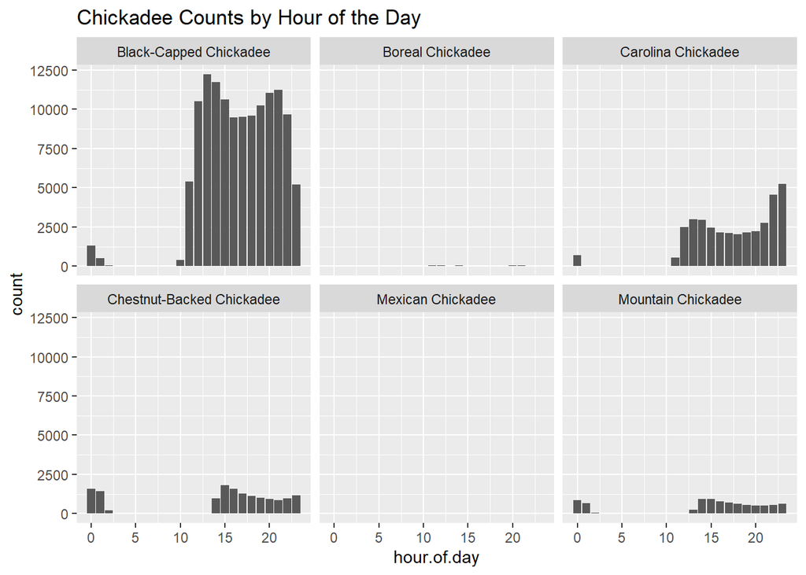

```r
df.birds %>%
  filter(str_detect(species, 'Chickadee')) %>%
  ggplot(aes(x = hour.of.day)) +
  geom_bar() +
  facet_wrap(~species) +
  labs(title = 'Chickadee Counts by Hour of the Day')
```

## Problem 12.2 - Chickadee Ranges (Centroids)

Write a `dplyr` pipeline, using `sf` functions, to calculate the *centroid* of each Chickadee species’ home range.

**Hint:** As each row (feature) in the `birds` dataset has a single Point geometry, and we want to calculate the geographic center (an average) of all those geometries, we first need a way of collecting all those Points into a MultiPoint geometry…

## Solution 12.2

```r
birds %>%
  filter(str_detect(species, 'Chickadee')) %>%
  group_by(species) %>%
  summarize(geometry = st_union(geometry)) %>%
  mutate(geometry = st_centroid(geometry),
    longitude = st_coordinates(geometry)[,1],
    latitude = st_coordinates(geometry)[,2])
```

```
## Simple feature collection with 6 features and 3 fields
## Geometry type: POINT
## Dimension:     XY
## Bounding box:  xmin: -122.0637 ymin: 26.27256 xmax: -78.67648 ymax: 45.86747
## Geodetic CRS:  WGS 84
## # A tibble: 6 × 4
##   species                               geometry longitude latitude
## * <chr>                              <POINT [°]>     <dbl>    <dbl>
## 1 Black-Capped Chickadee    (-83.61547 42.78654)     -83.6     42.8
## 2 Boreal Chickadee          (-78.67648 45.86747)     -78.7     45.9
## 3 Carolina Chickadee        (-86.35593 34.70883)     -86.4     34.7
## 4 Chestnut-Backed Chickadee (-122.0637 43.68375)    -122.      43.7
## 5 Mexican Chickadee         (-104.5785 26.27256)    -105.      26.3
## 6 Mountain Chickadee        (-117.3899 40.83587)    -117.      40.8
```

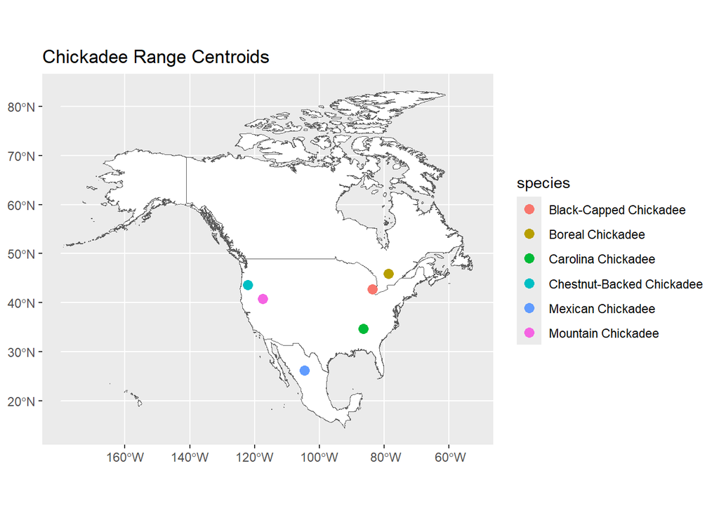

```r
ggplot() +
  geom_sf(data = countries, fill = 'white') +
  geom_sf(data = birds %>%
    filter(str_detect(species, 'Chickadee')) %>%
    group_by(species) %>%
    summarize(geometry = st_union(geometry)) %>%
    mutate(geometry = st_centroid(geometry)),
    aes(color = species), size = 3) +
  labs(title = 'Chickadee Range Centroids')
```

## Problem 12.3 - Jay Ranges (Envelopes)

```r
jays <- c('Blue Jay', 'Canada Jay', 'Stellers Jay', 'California Scrub-Jay', 'Pinyon Jay')
```

Your map should show the home ranges overlaid on top of the `countries` layer.

**Hint:** You may need to make use of the `st_union()` and `st_convex_hull()` functions.

**Hint:** You may want to adjust the `alpha` of the home-ranges layer, to help see overlapping home ranges.

## Solution 12.3

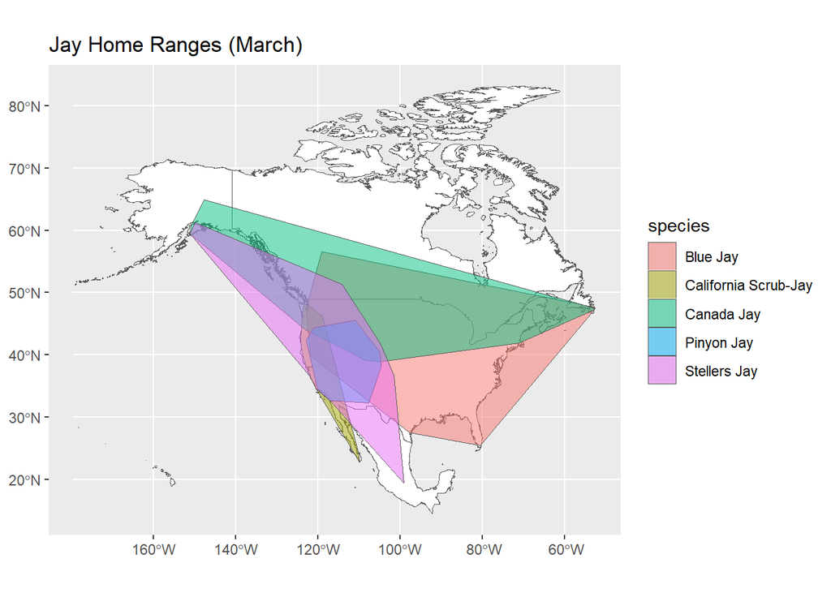

```r
jay.ranges <- birds %>%
  filter(species %in% jays) %>%
  group_by(species) %>%
  summarize(geometry = st_union(geometry)) %>%
  mutate(geometry = st_convex_hull(geometry))

ggplot() +
  geom_sf(data = countries, fill = 'white') +
  geom_sf(data = jay.ranges, aes(fill = species), alpha = 0.5) +
  labs(title = 'Jay Home Ranges (March)')
```

## Problem 12.4 - Jay Ranges Relative to Blue Jays

There are four Jay species whose March ranges overlap with that of the Blue Jay: `"California Scrub-Jay"`, `"Canada Jay"`, `"Pinyon Jay"`, and `"Stellers Jay"`.

1. **Project the BirdBuddy data to Albers Equal-Area Conic projection** (using the `albers` CRS, below).
2. **Plot the intersection of each Jay species’ home range with that of the Blue Jay.** Show a separate plot for each intersection, using the Albers projection.
3. **Report the area of the intersection for each species.**

**Hint:** There should be four plots because there are four Jay species with home ranges overlapping that of the Blue Jay.

```r
albers <- st_crs('+proj=aea +lat_0=40 +lon_0=-96 +lat_1=20 +lat_2=60 +x_0=0 +y_0=0 +datum=NAD83 +units=m +no_defs +type=crs')
```

## Solution 12.4

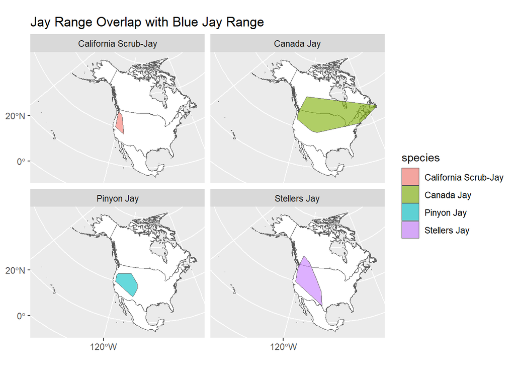

```r
birds.albers <- st_transform(birds, albers)
countries.albers <- st_transform(countries, albers)

jay.ranges.albers <- birds.albers %>%
  filter(species %in% jays) %>%
  group_by(species) %>%
  summarize(geometry = st_convex_hull(st_union(geometry)), .groups = 'drop')

blue.jay.range <- jay.ranges.albers %>%
  filter(species == 'Blue Jay')

jay.intersections <- jay.ranges.albers %>%
  filter(species != 'Blue Jay') %>%
  mutate(geometry = st_intersection(geometry, st_geometry(blue.jay.range)),
    area.sq.km = as.numeric(st_area(geometry)) / 1000000)

ggplot() +
  geom_sf(data = countries.albers, fill = 'white') +
  geom_sf(data = jay.intersections, aes(fill = species), alpha = 0.6) +
  facet_wrap(~species) +
  labs(title = 'Jay Range Overlap with Blue Jay Range')
```

```r
jay.intersections %>%
  st_drop_geometry() %>%
  select(Species = species, `Overlap Area with Blue Jay (sq km)` = area.sq.km)
```

```
## # A tibble: 4 × 2
##   Species              `Overlap Area with Blue Jay (sq km)`
##   <chr>                                               <dbl>
## 1 California Scrub-Jay                              406192.
## 2 Canada Jay                                       7098794.
## 3 Pinyon Jay                                       1228924.
## 4 Stellers Jay                                     2383413.
```

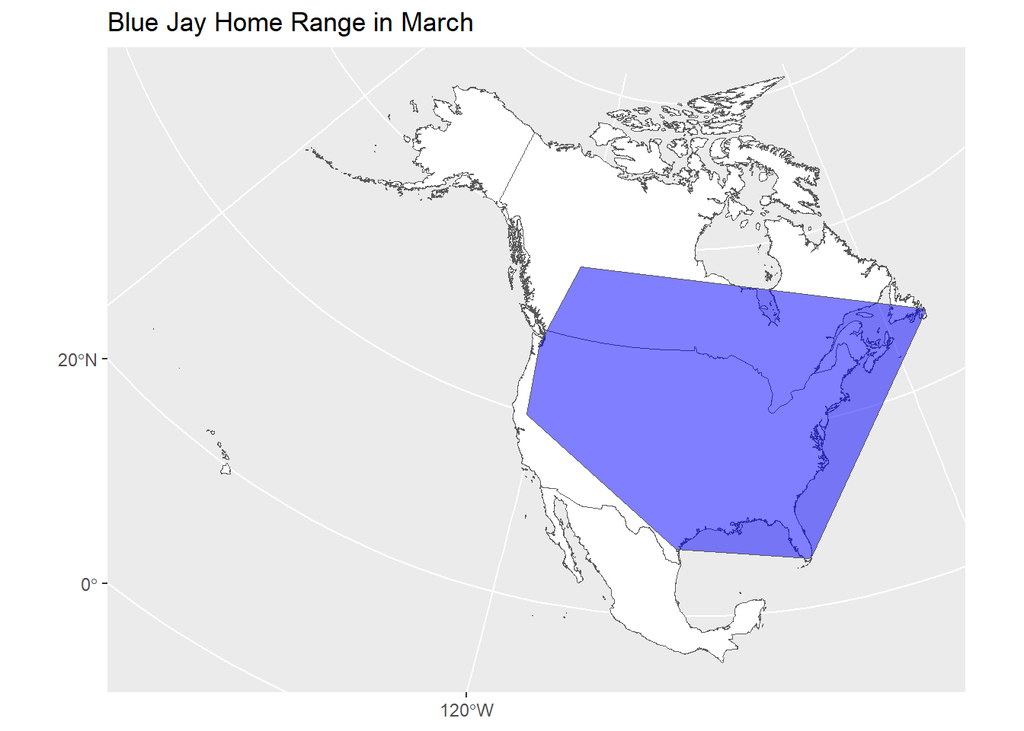

```r
ggplot() +
  geom_sf(data = countries.albers, fill = 'white') +
  geom_sf(data = blue.jay.range, fill = 'blue', alpha = 0.5) +
  labs(title = 'Blue Jay Home Range in March')
```

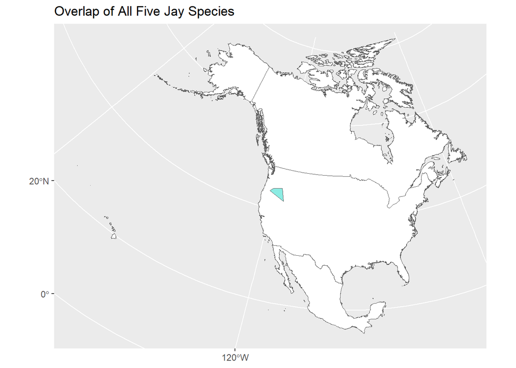

```r
all.jay.overlap <- st_sf(
  geometry = st_sfc(Reduce(st_intersection, st_geometry(jay.ranges.albers))),
  crs = st_crs(jay.ranges.albers)
)

ggplot() +
  geom_sf(data = countries.albers, fill = 'white') +
  geom_sf(data = all.jay.overlap, fill = 'turquoise', alpha = 0.6) +
  labs(title = 'Overlap of All Five Jay Species')
```